# Describing Data

## Describing Distributions

- **Shape**: modality, skewness
- **Center**: mean, median, mode
- **Spread**: variance, sd, range, IQR
- **Unusual observations**: outliers

## Shape

**Modality**

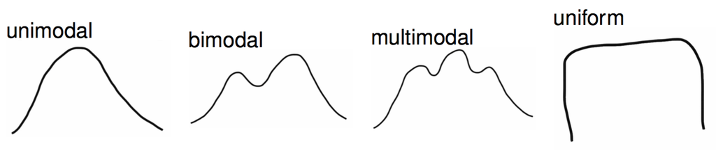

**Skewness**

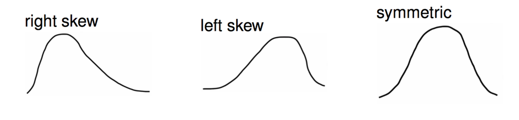

## Shape Q

Which of these variables do you expect to be uniformly distributed?

1. weights of adult females
2. salaries of a random sample of people from Oregon
3. house prices
4. birthdays of classmates (day of the month)

## Center: mean

```r
X <- c(8, 11, 7, 7, 8, 11, 9, 6, 10, 7, 9)
```

\[ \frac{8 + 11 + 7 + 7 + 8 + 11 + 9 + 6 + 10 + 7 + 9}{11} = \frac{93}{11} = 8.45 \\ \\ \]

**Sample mean**: the arithmetic mean of the data (vs *pop mean*)

\[ \bar{x} = \frac{x_1 + x_2 + \ldots + x_n}{n} \quad \quad \textrm{vs.} \quad \quad \mu\]

```r
mean(X)
```

```
## [1] 8.5
```

## Center: median

**Median**: the middle value of a sorted data set.

```r
sort(X)
```

```
##  [1]  6  7  7  7  8  8  9  9 10 11 11
```

```r
median(X)
```

```
## [1] 8
```

Break ties by averaging middle two if necessary.

## Center: mode

**Mode**: the most frequently observed value in the data set.

```r
table(X)
```

```
## X
##  6  7  8  9 10 11
##  1  3  2  2  1  2
```

## The Typical Human

(https://www.youtube.com/watch?v=4B2xOvKFFz4)

Keep note of the measures of "typical" that are reported - they come quick!

## Spread: variance

**Sample variance**: roughly, the mean squared deviation from the mean.

\[ s^2 = \frac{\sum_{i=1}^{n} (x_i - \bar{x})^2}{n - 1}\]

Compare to the *population variance*, \(\sigma^2\), which divides by \(n\).

## Spread: variance

```r
X - mean(X)
```

```
##  [1] -0.45  2.55 -1.45 -1.45 -0.45  2.55  0.55 -2.45  1.55 -1.45  0.55
```

```r
(X - mean(X))^2
```

```
##  [1] 0.21 6.48 2.12 2.12 0.21 6.48 0.30 6.02 2.39 2.12 0.30
```

```r
sum((X - mean(X))^2) / (length(X) - 1)
```

```
## [1] 2.9
```

```r
var(X)
```

```
## [1] 2.9
```

## Spread: standard deviation

**Sample standard deviation**: the square root of the variance. Used because units are the same as the data.

\[ s = \sqrt(s^2) \]

```r
sqrt(var(X))
```

```
## [1] 1.7
```

```r
sd(X)
```

```
## [1] 1.7
```

Compared to the *population standard deviation*, \(\sigma\).

## Spread: IQR

**Inner Quartile Range**: the range of the middle 50% of the data.

\[ IQR = Q3 - Q1 \]

```r
sort(X)
```

```
##  [1]  6  7  7  7  8  8  9  9 10 11 11
```

```r
IQR(X)
```

```
## [1] 2.5
```

## Spread: range

**Range**: the range of the full data set.

\[ range = max - min \]

```r
max(X) - min(X)
```

```
## [1] 5
```

```r
range(X)
```

```
## [1]  6 11
```

## Spread Q

Which measure(s) of spread would be sensitive to the presence of outliers?

1. variance
2. standard deviation
3. IQR
4. Range

## Spread Q

```r
X
```

```
##  [1]  8 11  7  7  8 11  9  6 10  7  9
```

```r
Y
```

```
##  [1] 37 11  7  7  8 11  9  6 10  7  9
```

```r
var(X)
```

```
## [1] 2.9
```

```r
var(Y)
```

```
## [1] 77
```

## Spread Q

```r
IQR(X)
```

```
## [1] 2.5
```

```r
IQR(Y)
```

```
## [1] 3.5
```

```r
range(X)
```

```
## [1]  6 11
```

```r
range(Y)
```

```
## [1]  6 37
```

## Spread Q

Which measure(s) of spread would be sensitive to the presence of outliers?

1. **variance**
2. **standard deviation**
3. IQR
4. **Range**

## Center Q

Which measure(s) of center would be sensitive to the presence of outliers?

1. mean
2. median
3. mode

## Center Q

Which measure(s) of center would be sensitive to the presence of outliers?

1. **mean**
2. median
3. mode

## Mean vs median

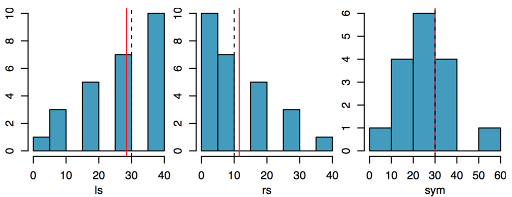

The mean (red line) is sensitive to extreme values, so it gets pulled towards the tail. The median (dashed line) is less sensitive.

For symmetric dists, use *mean* and *sd*.

For skewed dists, use *median* and *iqr*.

## Practice

- Find your numerical pair
- Work through the practice problems